# PD5

Szymon Maksymiuk

7 May 2019

```r
library(rpart)
library(mlr)
library(mlrMBO)
library(DALEX)
library(dplyr)
library(OpenML)
library(kableExtra)
library(rpart.plot)

set.seed(1234)


s <- sample(nrow(titanic), 0.7*nrow(titanic))
train_titanic <- select(titanic[s,], -c(country))
test_titanic <- select(titanic[-s,], -c(country))
```

# 1 Wstep

W tym raporcie przyjrze sie szerzej drzewom, a konkretiej implementacji `rpart`. W pracy posluze sie glównie wiedza zaczerpnieta z artykulu https://arxiv.org/pdf/1802.09596.pdf, z którym szczesliwie spotkalem sie juz wczesniej. Jako wrappera uzyja pakietu `mlr`.

Jako zbiór danych uzyje`titanic` dostepny w pakiecie `DALEX`. Zbiór ten jest przedmiotem zadania kasyfikacyjnego. Zajmijemy sie przewidywaniem czy osoba przetrwala rejs na Tytaniku. Podzielilem zbiór w proporcjach 7:3 chcac uniknac strojenia parametrów na danych testowych. Z oryginalnego zbiorór `titanic` usunalem kolumne `country` jako posiadajaca zbyt wiele unikalnych wartosci.

```r
kable(head(train_titanic)) %>%
  kable_styling(bootstrap_options = c("striped", "hover", "condensed"))
```

|  | gender | age | class | embarked | fare | sibsp | parch | survived |
| --- | --- | --- | --- | --- | --- | --- | --- | --- |
| 251 | male | 37 | 1st | Southampton | 25.1109 | 0 | 0 | no |
| 1373 | male | 24 | engineering crew | Southampton | 0.0000 | 0 | 0 | yes |
| 1344 | male | 28 | victualling crew | Southampton | 0.0000 | 0 | 0 | yes |
| 1374 | male | 31 | victualling crew | Southampton | 0.0000 | 0 | 0 | no |
| 1897 | male | 44 | victualling crew | Belfast | 0.0000 | 0 | 0 | no |
| 1410 | male | 38 | victualling crew | Southampton | 0.0000 | 0 | 0 | no |

```r
task <- makeClassifTask(id = "titanic", train_titanic, "survived")
```

# 2 Parametry

Na poczatek zapoznalem sie z parametrami, które bedziemy stroic, konkretniej z tym w jaki sposób wplywaja na model.

- **cp** - parametr zlozonosci. Parametr ten definiuje minimalna zmiane czynnika niedopasowania, której nowy proponowany podzal musi dokonac aby pozostal zachowany. To znaczy, ze te podzialy, które zmniejsza ten poziom o mniej niz stanowi wartosci **cp**, sa odrzucane.
- **maxdepth** - Oznacza maksymalna glebokosc kazdego wezla w ostatecznym drzewie, przy czym korzen ma zawsze glebokosc 0. Wartosci, wieksze niz 30 zwróca losowe wyniki na maszynach 32-bitowych.
- **minbucket** - Minimalny rozmiar liscia. Jezeli nowy podzial zmniejszy liczbe osberwacji w lisciu ponizej tej wartosci to nie zostanie dokonany.
- **minsplit** - Minimalna liczba obserwacji w wezle ponizej której nie wykonywane sa juz nowe podzialy.

# 3 Modele

Wszystkie model bedziemy porównywac za pomoca dwóch metryk, **acc** oraz **auc**.

## 3.1 Parametry zaproponowane

Sprawdzmy jak poradzi sobie model na parametrach zaproponowanych w artykule.

```r
set.seed(1234, "L'Ecuyer")
lrn_param <- makeLearner("classif.rpart", par.vals = list(cp = 0, maxdepth = 21, minbucket = 12, minsplit = 24), predict.type = "prob")
model_param <- train(lrn_param, task)
preds <- predict(model_param, newdata = test_titanic)
performance(preds, measures = list(auc, acc))
```

```
##       auc       acc
## 0.7852307 0.8009050
```

Jak widzimy model nie poradzil sobie najgorzej. Wynik auc w granicach 0.8 to calkiem przyzwoite i biznesowo akceptowalne rozwiazanie.

## 3.2 Parametry domyslne

Sprawdzmy teraz parametry domyslne.

```r
set.seed(1234, "L'Ecuyer")
lrn_def <- makeLearner("classif.rpart",  predict.type = "prob")
model_def <- train(lrn_def, task)
preds <- predict(model_def, newdata = test_titanic)
performance(preds, measures = list(auc, acc))
```

```
##       auc       acc
## 0.7856565 0.8039216
```

Co ciekawe wynik jest jest niemal identyczny. Model jest wrecz delitaknie lepszy. Bardzo ciekawe odkrycie.

## 3.3 Losowe wyszukiwanie

Sprawdzmy jeszcze losowe przeszukiwanie po zaproponowanej w artykule siatce parametrów.

```r
lrn_rand <- makeLearner("classif.rpart",  predict.type = "prob")

par.set <- makeParamSet(
  makeNumericParam("cp", 0, 1),
  makeIntegerParam("maxdepth", 1, 30),
  makeIntegerParam("minsplit", 1, 60),
  makeIntegerParam("minbucket", 1, 60)
)
set.seed(1234, "L'Ecuyer")

cv <- makeResampleDesc("CV", iters = 3L)
ctrl <- makeTuneControlRandom(maxit = 500L)
res <- tuneParams(lrn_rand, task, cv, par.set = par.set, control = ctrl)
lrn_rand <- setHyperPars(lrn_rand, par.vals = res$x)
model_rand <- train(lrn_rand, task)
preds <- predict(model_rand, newdata = test_titanic)
performance(preds, measures = list(auc, acc))
```

```
##       auc       acc
## 0.7673499 0.7948718
```

```r
kable(data.frame(res$x))
```

| cp | maxdepth | minsplit | minbucket |
| --- | --- | --- | --- |
| 0.0082212 | 7 | 27 | 18 |

Wynik z losowo strojonymi parametrami okazal sie gorszy od poprzednich modeli.

# 4 Wizualizacja oraz reguly decyzyjne

Zwizualizujmy teraz najlepsze drzewo, a wiec te z parametrami domyslnymi.

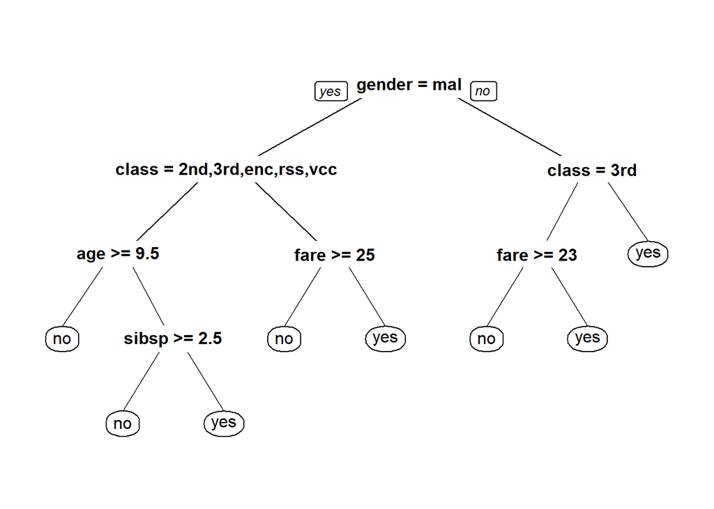

```r
prp(model_def$learner.model, roundint = FALSE)
```

```r
print(model_def$learner.model)
```

```
## n= 1544
##
## node), split, n, loss, yval, (yprob)
##       * denotes terminal node
##
##  1) root 1544 501 no (0.67551813 0.32448187)
##    2) gender=male 1205 246 no (0.79585062 0.20414938)
##      4) class=2nd,3rd,engineering crew,restaurant staff,victualling crew 1034 175 no (0.83075435 0.16924565)
##        8) age>=9.5 998 157 no (0.84268537 0.15731463) *
##        9) age< 9.5 36  18 no (0.50000000 0.50000000)
##         18) sibsp>=2.5 15   1 no (0.93333333 0.06666667) *
##         19) sibsp< 2.5 21   4 yes (0.19047619 0.80952381) *
##      5) class=1st,deck crew 171  71 no (0.58479532 0.41520468)
##       10) fare>=25.1608 120  39 no (0.67500000 0.32500000) *
##       11) fare< 25.1608 51  19 yes (0.37254902 0.62745098) *
##    3) gender=female 339  84 yes (0.24778761 0.75221239)
##      6) class=3rd 149  74 yes (0.49664430 0.50335570)
##       12) fare>=23.07 20   1 no (0.95000000 0.05000000) *
##       13) fare< 23.07 129  55 yes (0.42635659 0.57364341) *
##      7) class=1st,2nd,restaurant staff,victualling crew 190  10 yes (0.05263158 0.94736842) *
```

O ile mozna klócic sie o jakosc dostarczonego przez twórców pakietu `rpart` narzedzia do wyswietlenia regul to drzewo zostalo narysowane calkiem skladnie. Dodatkowo reguly moza równiez odczytac z obrazka.

# 5 Porównanie gini oraz information

Jako juz `gini` jest domyslnym kryterium podzialu, model taki juz posiadamy. Zostal on nawet zilustrowany w poprzednim rozdziale. Musimy zatem stworzyc jedynie model z `information` jako kryterium podzialu.

```r
set.seed(1234, "L'Ecuyer")
lrn_inf <- makeLearner("classif.rpart", parms = list(split = 'information'),  predict.type = "prob")
model_inf <- train(lrn_inf, task)
preds <- predict(model_inf, newdata = test_titanic)
performance(preds, measures = list(auc, acc))
```

```
##       auc       acc
## 0.7914065 0.8054299
```

Co ciekawe wartosc `auc` wzrosla o okolo jedna setna. Porównajmy teraz wyglad drzewa oraz reguly decyzyjne.

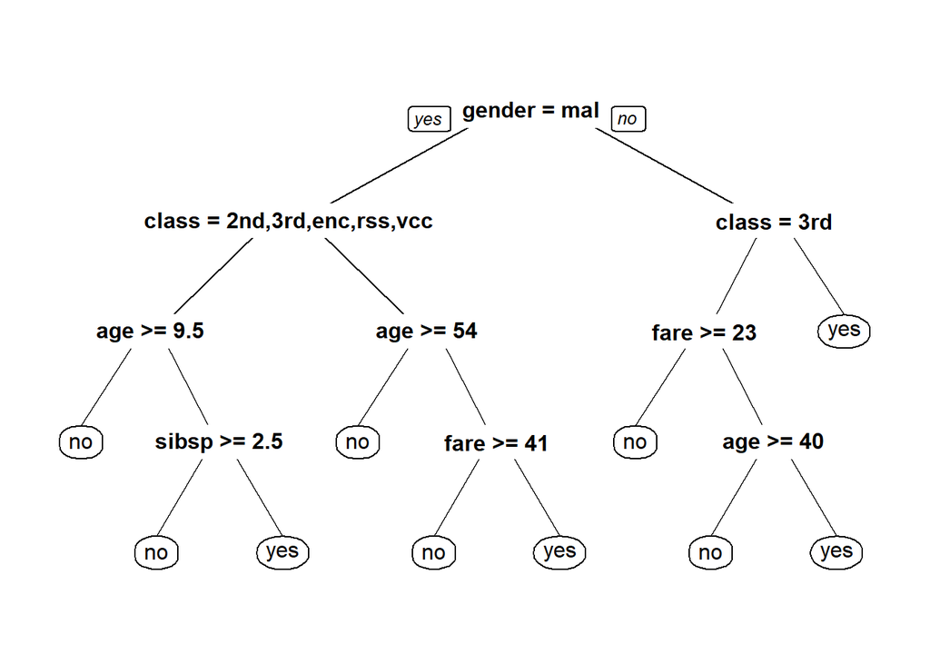

```r
prp(model_inf$learner.model, roundint = FALSE)
```

Drzewo zbudwane za pomoca kryterium podzialu `information` jest bardziej zbalansowane. Trzeci poziom zamiast jednego wezla jak w przypadku `gini` zawiera trzy wezly. Powstala równiez druga regula dotyczaca zmiennej wiek.